# Randomized controlled trials (RCTs)

2024-06-14

# 1 Introducción

Un ensayo aleatorio es aquel en el que la exposición (causa) de interés se asigna aleatoriamente.

**¿Por qué ayuda la aleatorización?**

Si observamos nuestros supuestos de causalidad, los ensayos aleatorios resuelven la parte de coherencia de la exposición bien definida de forma predeterminada: la exposición es exactamente lo que se aleatoriza. Lo mismo ocurre con la positividad; Si hemos asignado personas al azar a los grupos expuestos o no expuestos, conocemos la probabilidad de asignación (y sabemos que no es exactamente 0 o 1). La aleatorización por sí sola no resuelve la parte de interferencia de la coherencia (por ejemplo, si aleatorizamos a algunas personas para que reciban una vacuna contra una enfermedad transmisible, recibirla podría reducir la posibilidad de que quienes los rodean contraigan la enfermedad infecciosa porque cambia la probabilidad de exposición).

Los ensayos aleatorios ideales resuelven la cuestión de la intercambiabilidad porque las poblaciones expuestas y no expuestas (en el límite) son inherentemente las mismas, ya que su estado de exposición se determinó mediante un proceso aleatorio (no por ningún factor que pudiera hacerlas diferentes entre sí).

¡Excelente!

En realidad, a menudo vemos que esta suposición es violada por cuestiones como el abandono o la falta de adherencia en los ensayos aleatorios. Si hay un abandono diferencial entre los grupos de exposición (por ejemplo, si los participantes asignados aleatoriamente al tratamiento tienen más probabilidades de abandonar un estudio y, por lo tanto, no observamos su resultado), entonces los grupos de exposición observados ya no son intercambiables. Por lo tanto, en la siguiente tabla tenemos dos columnas, una para el ensayo aleatorio ideal (donde se supone que la adherencia es perfecta y ningún participante abandona) y otra para los ensayos aleatorios realistas donde esto puede no ser así.

| Suposición | Ensayo.aleatorio.ideal | Ensayo.aleatorio.realista | Estudio.observacional |
| --- | --- | --- | --- |
| Consistencia (exposición bien definida) | 😄 | 😄 | 🤷 |
| Consistencia (sin interferencias) | 🤷 | 🤷 | 🤷 |
| Positividad | 😄 | 😄 | 🤷 |
| Intercambiabilidad | 😄 | 🤷 | 🤷 |

Al diseñar un estudio, el primer paso es formular una pregunta causal adecuada . Luego podemos asignar esta pregunta a un protocolo , que consta de los siguientes siete elementos, tal como lo definen Hernán y Robins ( 2016 ) :

- Criterio de elegibilidad
- Definición de exposición
- Procedimientos de asignación
- Período de seguimiento
- Definición de resultados
- Contraste causal de intereses
- Plan de análisis

En el siguiente cuadro asignamos cada uno de estos elementos al supuesto correspondiente que puede abordar. Por ejemplo, la intercambiabilidad puede abordarse mediante los criterios de elegibilidad (podemos restringir nuestro estudio solo a participantes para quienes la asignación de exposición es intercambiable), el procedimiento de asignación (podríamos usar una asignación de exposición aleatoria para garantizar la intercambiabilidad), el período de seguimiento (podemos ser asegurarnos de elegir un momento de inicio apropiado para nuestro período de seguimiento para asegurarnos de que no induzcamos sesgos; pensaremos más en esto en un capítulo futuro) y/o el plan de análisis (podemos ajustar cualquier factor que causar que aquellos en diferentes grupos de exposición carezcan de intercambiabilidad).

| Suposición | Criterio.de.elegibilidad | Definición.de.exposición | Procedimientos.de.asignación | Período.de.seguimiento | Definición.de.resultados | Contraste.causal | Plan.de.análisis |
| --- | --- | --- | --- | --- | --- | --- | --- |
| Consistencia (exposición bien definida) | ✔️ | ✔️ |  |  |  |  |  |
| Consistencia (sin interferencias) |  | ✔️ | ✔️ |  | ✔️ |  | ✔️ |
| Positividad | ✔️ |  | ✔️ |  |  |  | ✔️ |
| Intercambiabilidad | ✔️ |  | ✔️ | ✔️ |  |  | ✔️ |

# 2 RCTs objetivo

Hay muchas razones por las que la aleatorización puede no ser posible. Por ejemplo, puede que no sea ético asignar personas al azar a una exposición particular, puede que no haya fondos disponibles para realizar un ensayo aleatorio o puede que no haya tiempo suficiente para realizar un ensayo completo. En estas situaciones, confiamos en datos de observación para ayudarnos a responder preguntas causales mediante la implementación de un ensayo objetivo .

Un ensayo objetivo responde: ¿Qué experimento diseñarías si pudieras? Especificar un ensayo objetivo es casi idéntico al proceso que describimos para un ensayo aleatorio. Definimos la elegibilidad, la exposición, el período de seguimiento, el resultado, la estimación de interés y el plan de análisis. La diferencia clave con el ensayo objetivo en el entorno observacional, por supuesto, es que no podemos asignar la exposición. El paso de planificación del análisis y ejecución de la prueba objetivo es el más complicado desde el punto de vista técnico; por ejemplo, usar DAG para garantizar que hemos medido y estamos controlando el conjunto correcto de factores de confusión, redactar programas estadísticos que invocan un método de ajuste apropiado, como la ponderación de IP, y realizar análisis de sensibilidad para evaluar qué tan sensibles son nuestras conclusiones a errores de especificación o confusión no medidos.

## 2.1 Inferencia causal con group_by() y summarize()

Supongamos que estamos tratando de estimar un efecto causal de una exposición sobre un resultado, pero la exposición no es aleatoria ; de hecho, hay una causa común de la exposición y el resultado, lo que hace que los grupos expuestos y no expuestos no sean intercambiables sin ajuste

### 2.1.1 Un confusor binario

Supongamos que este factor de confusión es binario; consulte la simulación a continuación:

```r
set.seed(1)
library(tidyverse)
library(dplyr)
n <- 10000
sim <- tibble::tibble(
  # generate the confounder from a binomial distribution
  # with a probability 0.5 for being in either group
  confounder = rbinom(n, 1, 0.5),
  # make the probability of exposure dependent on the
  # confounder value
  p_exposure = case_when(
    confounder == 1 ~ 0.75,
    confounder == 0 ~ 0.25
  ),
  # generate the exposure from a binomial distribution
  # with the probability of exposure dependent on the confounder
  exposure = rbinom(n, 1, p_exposure),
  # generate the "true" average treatment effect of 0
  # to do this, we are going to generate the potential outcomes, first
  # the potential outcome if exposure = 0
  # (notice exposure is not in the equation below, only the confounder)
  # we use rnorm(n) to add the random error term that is normally
  # distributed with a mean of 0 and a standard deviation of 1
  y0 = confounder + rnorm(n),
  # because the true effect is 0, the potential outcome if exposure = 1
  # is identical
  y1 = y0,
  # now, in practice we will only see one of these, outcome is what is
  # observed
  outcome = (1 - exposure) * y0 + exposure * y1,
  observed_potential_outcome = case_when(
    exposure == 0 ~ "y0",
    exposure == 1 ~ "y1"
  )
)
```

Aquí tenemos un factor de confusión binario, la probabilidad de que el factor de confusión = 1 sea 0,5. La probabilidad de estar expuesto es de 0,75 para aquellos para los que el factor de confusión = 1 y de 0,25 para aquellos para los que el factor de confusión = 0. No hay efecto de la exposición sobre el resultado (el verdadero efecto causal es 0); el efecto del resultado depende totalmente del factor de confusión.

En esta simulación generamos los resultados potenciales para hacer realidad nuestras suposiciones; Muchas de nuestras simulaciones en este libro omitirán este paso. Veamos este marco de datos generado.

```r
sim |>
  select(confounder, exposure, outcome, observed_potential_outcome)
```

| confounder | exposure | outcome | observed_potential_outcome |
| --- | --- | --- | --- |
| 0 | 0 | -0.8043315998 | y0 |
| 0 | 0 | -1.0565256542 | y0 |
| 1 | 1 | -0.0353957841 | y1 |
| 1 | 1 | -0.1855603536 | y1 |
| 0 | 0 | -0.5004395117 | y0 |
| 1 | 1 | 0.4750112929 | y1 |
| 1 | 0 | 0.6975670435 | y0 |
| 1 | 0 | 1.4719681324 | y0 |
| 1 | 0 | 0.7516160512 | y0 |
| 0 | 0 | 1.2593180295 | y0 |

[output cut: 9990 more lines]

¡Excelente! Comencemos por demostrarnos a nosotros mismos que esto viola el supuesto de intercambiabilidad.

**Recuerda:**

*Intercambiabilidad : asumimos que dentro de los niveles de variables relevantes (factores de confusión), los sujetos expuestos y no expuestos tienen la misma probabilidad de experimentar cualquier resultado antes de la exposición; es decir, los sujetos expuestos y no expuestos son intercambiables. A veces se hace referencia a este supuesto como que no hay confusión no medida , aunque la intercambiabilidad implica más que eso, como que no hay sesgo de selección y que las relaciones de confusión se especifican adecuadamente. Definiremos con más detalle la intercambiabilidad a través de la lente de los DAG en el próximo capítulo.*

Ahora, intentemos estimar el efecto de exposureen outcomesuponiendo que los dos grupos expuestos son intercambiables.

```r
sim |>
  group_by(exposure) |>
  summarise(avg_outcome = mean(outcome))
```

| exposure | avg_outcome |
| --- | --- |
| 0 | 0.2278087 |
| 1 | 0.7561017 |

El resultado promedio entre los expuestos es 0.76y entre los no expuestos 0.23, lo que arroja un efecto promedio de la exposición de 0.76-0.23=0.53. Hagamos un poco de trabajo de R para llegar allí.

```r
sim |>
  group_by(exposure) |>
  summarise(avg_outcome = mean(outcome)) |>
  pivot_wider(
    names_from = exposure,
    values_from = avg_outcome,
    names_prefix = "x_"
  ) |>
  summarise(estimate = x_1 - x_0)
```

| estimate |
| --- |
| 0.5282931 |

Bien, suponiendo que los grupos de exposición sean intercambiables (y suponiendo que se cumplan el resto de los supuestos), estimamos que el efecto de la exposición sobre el resultado es 0,53. Sabemos que se viola el supuesto de intercambiabilidad según cómo simulamos los datos. ¿Cómo podemos estimar un efecto insesgado? La forma más sencilla de hacerlo es estimar el efecto dentro de cada clase de factor de confusión. Esto funcionará porque las personas con el mismo valor del factor de confusión tienen la misma probabilidad de exposición. En lugar de simplemente agrupar por exposición, agrupemos también por factor de confusión:

```r
sim |>
  group_by(confounder, exposure) |>
  summarise(avg_outcome = mean(outcome))
```

| confounder | exposure | avg_outcome |
| --- | --- | --- |
| 0 | 0 | -0.018467415 |
| 0 | 1 | 0.009539361 |
| 1 | 0 | 0.994090633 |
| 1 | 1 | 1.006289135 |

Ahora podemos calcular el efecto promedio dentro de cada clase de factor de confusión, así como el efecto causal general.

```r
## Average effect within each confounder class
sim |>
  group_by(confounder, exposure) |>
  summarise(avg_outcome = mean(outcome)) |>
  pivot_wider(
    names_from = exposure,
    values_from = avg_outcome,
    names_prefix = "x_"
  ) |>
  summarise(estimate = x_1 - x_0)
```

| confounder | estimate |
| --- | --- |
| 0 | 0.02800678 |
| 1 | 0.01219850 |

```r
## Overall average effect

sim |>
  group_by(confounder, exposure) |>
  summarise(avg_outcome = mean(outcome)) |>
  pivot_wider(
    names_from = exposure,
    values_from = avg_outcome,
    names_prefix = "x_"
  ) |>
  summarise(estimate = x_1 - x_0) |>
  summarise(mean(estimate)) # note, we would need to weight this if the confounder groups were not equal sized
```

| mean(estimate) |
| --- |
| 0.02010264 |

¡Excelente! Ahora nuestra estimación está mucho más cerca del valor real (0).

*El método que estamos utilizando para resolver el hecho de que nuestros dos grupos no son intercambiables se conoce como estratificación . Estamos estratificando por los factores de confusión y estimando el efecto causal dentro de cada estrato. Para obtener un efecto causal promedio general, estamos promediando todos los estratos. Esta puede ser una gran herramienta si hay muy pocos factores de confusión; sin embargo, puede sufrir la maldición de la dimensionalidad a medida que aumenta el número de factores de confusión y el número de niveles dentro de cada factor de confusión.*

### 2.1.2 Dos factores de confusión binarios

Extendamos esto a dos factores de confusión binarios. La siguiente simulación ahora tiene dos factores de confusión binarios. El verdadero efecto causal de exposure sobre outcome sigue siendo 0.

```r
set.seed(1)
n <- 10000
sim2 <- tibble(
  confounder_1 = rbinom(n, 1, 0.5),
  confounder_2 = rbinom(n, 1, 0.5),
  p_exposure = case_when(
    confounder_1 == 1 & confounder_2 == 1 ~ 0.75,
    confounder_1 == 0 & confounder_2 == 1 ~ 0.9,
    confounder_1 == 1 & confounder_2 == 0 ~ 0.2,
    confounder_1 == 0 & confounder_2 == 0 ~ 0.1,
  ),
  exposure = rbinom(n, 1, p_exposure),
  outcome = confounder_1 + confounder_2 + rnorm(n)
)
```

Ahora vamos a agrupar por ambos factores de confusión y estimar el efecto causal dentro de cada estrato.

```r
sim2 |>
  group_by(confounder_1, confounder_2, exposure) |>
  summarise(avg_y = mean(outcome)) |>
  pivot_wider(
    names_from = exposure,
    values_from = avg_y,
    names_prefix = "x_"
  ) |>
  summarise(estimate = x_1 - x_0)
```

| confounder_1 | confounder_2 | estimate |
| --- | --- | --- |
| 0 | 0 | -0.12196667 |
| 0 | 1 | 0.04930320 |
| 1 | 0 | 0.02632562 |
| 1 | 1 | 0.02255917 |

También podemos estimar el efecto causal general:

```r
sim2 |>
  group_by(confounder_1, confounder_2, exposure) |>
  summarise(avg_outcome = mean(outcome)) |>
  pivot_wider(
    names_from = exposure,
    values_from = avg_outcome,
    names_prefix = "x_"
  ) |>
  summarise(estimate = x_1 - x_0, .groups = "drop") |>
  summarise(mean(estimate))
```

| mean(estimate) |
| --- |
| -0.005944669 |

### 2.1.3 Confusor continuo

Hasta ahora nuestra estrategia ha sido estimar el efecto causal dentro de los estratos donde los individuos son intercambiables . ¿Cómo podríamos extender esto a un factor de confusión continuo? Creemos otra simulación:

```r
set.seed(1)
n <- 10000
sim3 <- tibble(
  confounder = rnorm(n),
  p_exposure = exp(confounder) / (1 + exp(confounder)),
  exposure = rbinom(n, 1, p_exposure),
  outcome = confounder + rnorm(n)
)
sim3
```

| confounder | p_exposure | exposure | outcome |
| --- | --- | --- | --- |
| -6.264538e-01 | 0.34831506 | 0 | -8.403628e-01 |
| 1.836433e-01 | 0.54578224 | 1 | 7.692004e-02 |
| -8.356286e-01 | 0.30245625 | 0 | -1.300218e+00 |
| 1.595281e+00 | 0.83135778 | 1 | 9.110083e-01 |
| 3.295078e-01 | 0.58163961 | 1 | -4.612930e-01 |
| -8.204684e-01 | 0.30566424 | 0 | -1.159432e+00 |
| 4.874291e-01 | 0.61950060 | 1 | -7.800009e-01 |
| 7.383247e-01 | 0.67662941 | 1 | -6.557812e-01 |
| 5.757814e-01 | 0.64009612 | 1 | 9.947063e-01 |
| -3.053884e-01 | 0.42424078 | 0 | 2.909797e+00 |

[output cut: 9990 more lines]

Si queremos seguir usando group_byy summarise, podríamos agrupar el factor de confusión continuo, por ejemplo usando sus quintiles, y estimar el efecto causal dentro de cada grupo:

```r
sim3 |>
  mutate(confounder_q = ntile(confounder, 5)) |>
  group_by(confounder_q, exposure) |>
  summarise(avg_y = mean(outcome)) |>
  pivot_wider(
    names_from = exposure,
    values_from = avg_y,
    names_prefix = "x_"
  ) |>
  summarise(estimate = x_1 - x_0)
```

| confounder_q | estimate |
| --- | --- |
| 1 | 0.23661100 |
| 2 | 0.06219516 |
| 3 | 0.02644541 |
| 4 | 0.13337728 |
| 5 | 0.17755776 |

```r
sim3 |>
  mutate(confounder_q = ntile(confounder, 5)) |>
  group_by(confounder_q, exposure) |>
  summarise(avg_y = mean(outcome)) |>
  pivot_wider(
    names_from = exposure,
    values_from = avg_y,
    names_prefix = "x_"
  ) |>
  summarise(estimate = x_1 - x_0) |>
  summarise(estimate = mean(estimate))
```

| estimate |
| --- |
| 0.1272373 |

¡Excelente! Ahora bien, en la práctica tenemos muchos más de uno o dos factores de confusión binarios; a menudo tenemos muchos factores de confusión, tanto continuos como binarios. Intentar estimar el efecto causal dentro de cada estrato único sería muy ineficaz (¡y muchas veces imposible!). ¿Qué pasaría si, en cambio, pudiéramos crear una puntuación resumida única para todos los factores de confusión? Mantenga este pensamiento, lo mencionaremos nuevamente cuando presentemos las puntuaciones de propensión .

# 3 ¿Cuándo tienen éxito y cuándo fracasan los métodos estándar?

Al enseñar estos temas, a menudo nos preguntan cuándo tendrán éxito los “métodos estándar”, es decir: ¿cuándo podremos simplemente ajustar un modelo de regresión lineal para estimar un efecto causal? Comencemos con el ejemplo más sencillo: la exposición es aleatoria . Como se analizó previamente, la aleatorización garantiza la comparabilidad y puede simplificar los métodos necesarios para estimar un efecto causal. En presencia de una exposición aleatoria (suponiendo que se cumpla perfectamente la exposición asignada, que nadie abandone el estudio, etc.), se pueden utilizar herramientas simples como la regresión para estimar un efecto causal.

## 3.1 Cuando la correlación es causalidad

Cuando no hay factores de confusión y existe una relación lineal entre la exposición y el resultado, esa correlación es una relación causal. Incluso en estos casos, puede resultar útil utilizar los siguientes métodos:

1. Ajustar las covariables de referencia puede hacer que una estimación sea más eficiente
2. La ponderación del puntaje de propensión es más eficiente que el ajuste directo
3. A veces nos sentimos más cómodos con la forma funcional del puntaje de propensión (predecir la exposición) que con el modelo de resultados.

Veamos un ejemplo. Voy a simular 100 observaciones. Aquí el tratamiento se asigna aleatoriamente y hay dos covariables de referencia: age y weight. En promedio, el tratamiento provoca un aumento de una unidad en el resultado (esto se denomina efecto promedio del tratamiento).

```r
library(tidyverse)
set.seed(10)
n <- 100
d <- tibble(
  age = rnorm(n, 55, 20),
  weight = rnorm(n),
  # generate the treatment from a binomial distribution
  # with the probability of treatment = 0.5
  treatment = rbinom(n, 1, 0.5),
  # generate the average causal effect of treatment: 1
  y = 1 * treatment + 0.2 * age + 0.2 * weight + rnorm(n)
)
```

Examinemos tres modelos: (1) un modelo no ajustado, (2) un modelo lineal que se ajusta a las covariables de referencia y (3) un modelo ponderado por puntuación de propensión.

```r
library(gtsummary)
lm(y ~ treatment, d) |>
  tbl_regression() |>
  modify_column_unhide(column = std.error) |>
  modify_caption("Unadjusted regression")
```

Unadjusted regression

| **Characteristic** | **Beta** | **SE**<sup>1</sup> | **95% CI**<sup>1</sup> | **p-value** |
| --- | --- | --- | --- | --- |
| treatment | 0.93 | 0.803 | -0.66, 2.5 | 0.2 |

<sup>1</sup> SE = Standard Error, CI = Confidence Interval

```r
lm(y ~ treatment + age + weight, d) |>
  tbl_regression() |>
  modify_column_unhide(column = std.error) |>
  modify_caption("Adjusted regression")
```

Adjusted regression

| **Characteristic** | **Beta** | **SE**<sup>1</sup> | **95% CI**<sup>1</sup> | **p-value** |
| --- | --- | --- | --- | --- |
| treatment | 1.0 | 0.204 | 0.59, 1.4 | <0.001 |
| age | 0.20 | 0.005 | 0.19, 0.22 | <0.001 |
| weight | 0.34 | 0.106 | 0.13, 0.55 | 0.002 |

<sup>1</sup> SE = Standard Error, CI = Confidence Interval

```r
d |>
  mutate(
    p = glm(treatment ~ weight + age, data = d) |> predict(type = "response"),
    ate = treatment / p + (1 - treatment) / (1 - p)
  ) |>
  as.data.frame() -> d

library(PSW)
df <- as.data.frame(d)
x <- psw(
  df,
  "treatment ~ weight + age",
  weight = "ATE",
  wt = TRUE,
  out.var = "y"
)
tibble(
  Characteristic = "treatment",
  Beta = round(x$est.wt, 1),
  SE = round(x$std.wt, 3),
  `95% CI` = glue::glue("{round(x$est.wt - 1.96 * x$std.wt, 1)}, {round(x$est.wt + 1.96 * x$std.wt, 1)}"),
  `p-value` = "<0.001"
) |>
  knitr::kable(caption = "Propensity score weighted regression")
```

Propensity score weighted regression

| Characteristic | Beta | SE | 95% CI | p-value |
| --- | --- | --- | --- | --- |
| treatment | 1 | 0.202 | 0.6, 1.4 | <0.001 |

Al observar los tres resultados, podemos notar primero que los tres son estimaciones “insesgadas” del efecto causal (sabemos que el verdadero efecto promedio del tratamiento es 1, según nuestra simulación): el efecto causal estimado en cada tabla es en la columna Beta. Genial, todos los métodos nos dan una estimación imparcial. A continuación, veamos la columna SE (error estándar) junto con la columna 95% CI (intervalo de confianza). Observe que el modelo no ajustado tiene un intervalo de confianza más amplio (de hecho, en este caso el intervalo de confianza incluye el nulo, 0); esto significa que si usáramos este método, aunque pudiéramos estimar un efecto causal insesgado, A menudo concluimos que no podemos rechazar la nulidad de que la relación entre el tratamiento y el resultado es 0. En términos estadísticos, nos referimos a esto como falta de eficiencia .

Al observar el análisis ajustado, vemos que el error estándar es bastante menor (y de la misma manera el intervalo de confianza es más ajustado, ya que ya no incluye el valor nulo). Aunque nuestras covariables de referencia age y weight no eran factores de confusión, ajustarlas a partir de ellas aumentó la precisión de nuestro resultado (¡esto es algo bueno! Queremos estimaciones que sean imparciales y precisas). Finalmente, al observar la estimación ponderada del puntaje de propensión, podemos ver que nuestra precisión mejoró ligeramente en comparación con el resultado ajustado (0,202 en comparación con 0,204). La magnitud de esta mejora dependerá de varios factores, pero se ha demostrado matemáticamente que el uso de puntuaciones de propensión para ajustar los factores iniciales en un ensayo aleatorio siempre mejorará la precisión ( Williamson, Forbes y White 2014 ).

**¿Qué podemos aprender de esta pequeña demostración?** Incluso en el escenario perfecto, donde podamos estimar resultados insesgados sin utilizar puntuaciones de propensión, los métodos que mostraremos aquí pueden resultar útiles. La utilidad de estos métodos sólo aumenta cuando se exploran ejemplos más complejos, como situaciones en las que el efecto no es aleatorio, la introducción de factores de confusión que varían en el tiempo, etc.

**¿Qué pasaría si no tuviéramos una exposición aleatoria?** Hay muchos casos en los que la aleatorización de un tratamiento no es ética ni factible. Los métodos estándar aún pueden estimar efectos insesgados, pero es necesario prestar más atención a los supuestos mencionados anteriormente. Por ejemplo, necesitamos que los grupos expuestos y no expuestos sean intercambiables; esto significa que debemos ajustar todos los factores de confusión con su forma funcional correcta. Si todo es simple y lineal (y no hay heterogeneidad de efectos, es decir, el efecto causal de todos es el mismo independientemente de sus factores de referencia), entonces un modelo de regresión simple que se ajuste a los factores de confusión puede brindarle un resultado insesgado.

Veamos un ejemplo sencillo como este.

Observe que en la simulación a continuación, la principal diferencia en comparación con la simulación anterior es que la probabilidad de asignación del tratamiento ya no es 0,5 como antes, sino que ahora depende de los participantes agey weight. Por ejemplo, tal vez los médicos tiendan a prescribir un determinado tratamiento a pacientes de mayor edad y que pesan más. El verdadero efecto causal sigue siendo 1, pero ahora tenemos dos factores de confusión, age y weight.

```r
set.seed(7)
n <- 100000
d <- tibble(
  age = rnorm(n, 55, 20),
  weight = rnorm(n),
  # generate the treatment from a binomial distribution
  # with the probability of treatment dependent on the age and weight
  treatment = rbinom(n, 1, 1 / (1 + exp(-0.01 * age - weight))),
  ## generate the true average causal effect of the treatment: 1
  y = 1 * treatment + 0.2 * age + 0.2 * weight + rnorm(n)
)
```

```r
lm(y ~ treatment, d) |>
  tbl_regression() |>
  modify_column_unhide(column = std.error) |>
  modify_caption("Unadjusted regression")
```

Unadjusted regression

| **Characteristic** | **Beta** | **SE**<sup>1</sup> | **95% CI**<sup>1</sup> | **p-value** |
| --- | --- | --- | --- | --- |
| treatment | 1.8 | 0.027 | 1.8, 1.9 | <0.001 |

<sup>1</sup> SE = Standard Error, CI = Confidence Interval

```r
lm(y ~ treatment + age + weight, d) |>
  tbl_regression() |>
  modify_column_unhide(column = std.error) |>
  modify_caption("Adjusted regression")
```

Adjusted regression

| **Characteristic** | **Beta** | **SE**<sup>1</sup> | **95% CI**<sup>1</sup> | **p-value** |
| --- | --- | --- | --- | --- |
| treatment | 0.99 | 0.007 | 0.98, 1.0 | <0.001 |
| age | 0.20 | 0.000 | 0.20, 0.20 | <0.001 |
| weight | 0.20 | 0.003 | 0.20, 0.21 | <0.001 |

<sup>1</sup> SE = Standard Error, CI = Confidence Interval

```r
d |>
  mutate(
    p = glm(treatment ~ weight + age, data = d, family = binomial) |> predict(type = "response"),
    ate = treatment / p + (1 - treatment) / (1 - p)
  ) |>
  as.data.frame() -> d
library(PSW)
df <- as.data.frame(d)
x <- psw(
  df,
  "treatment ~ weight + age",
  weight = "ATE",
  wt = TRUE,
  out.var = "y"
)
tibble(
  Characteristic = "treatment",
  Beta = round(x$est.wt, 1),
  SE = round(x$std.wt, 3),
  `95% CI` = glue::glue("{round(x$est.wt - 1.96 * x$std.wt, 1)}, {round(x$est.wt + 1.96 * x$std.wt, 1)}"),
  `p-value` = "<0.001"
) |>
  knitr::kable(caption = "Propensity score weighted regression")
```

Propensity score weighted regression

| Characteristic | Beta | SE | 95% CI | p-value |
| --- | --- | --- | --- | --- |
| treatment | 1 | 0.014 | 1, 1 | <0.001 |

Aquí vemos que el efecto no ajustado está sesgado (difiere del efecto verdadero, 1, y el efecto verdadero no está contenido en el intervalo de confianza del 95% informado). Aademás, vemos que el modelo ajusto y con puntaje de propensión, ambos estiman efectos causales insesgados. El resultado de la columna Beta en el modelo ajustado es técnicamente un efecto condicional (y a menudo en la inferencia causal queremos efectos marginales), pero como no hay heterogeneidad de tratamiento en esta simulación, los efectos condicional y marginal son iguales.

El modelo con ponderación, utilizando el puntaje de propensión, también estima un efecto insesgado, pero ya no es el más eficiente ( eso era cierto cuando las covariables de referencia eran meramente causales para y, ahora que son confusoras, las ganancias de eficiencia al usar la ponderación del puntaje de propensión no son tan claros). Entonces, ¿por qué utilizaríamos puntuaciones de propensión en este caso? A veces comprendemos mejor la forma funcional del modelo de puntuación de propensión en comparación con el modelo de resultados.

Alternativamente, a veces el modelo de resultados es difícil de ajustar (por ejemplo, si el resultado es poco común).

### Efectos marginales versus condicionales

En la inferencia causal, a menudo nos interesan los efectos marginales ; matemáticamente, esto significa que queremos marginar el efecto de interés en la distribución de factores en una población particular para la que estamos tratando de estimar un efecto causal. En un modelo de regresión ajustado, los coeficientes son condicionales ; en otras palabras, cuando describimos el coeficiente estimado, a menudo decimos algo como “un cambio de una unidad en la exposición da como resultado un cambio de [valor delcoefficient] en el resultado manteniendo constantes todas las demás variables en el modelo”.

En el caso en que el resultado es continuo, el efecto es lineal y no hay interacciones entre el efecto de exposición y otros factores de la población, la distinción entre un efecto condicional y uno marginal es en gran medida semántica.

Si hay una interacción en el modelo, es decir, si la exposición tiene un impacto diferente en el resultado dependiendo de algún otro factor, ya no tenemos un único coeficiente para interpretar. Querríamos estimar un efecto marginal , teniendo en cuenta la distribución de ese factor en la población de interés.

**¿Por qué?**

En última instancia, estamos tratando de determinar si debemos sugerir la exposición a la población objetivo, por lo que queremos saber, en promedio , si será beneficiosa. Veamos un ejemplo rápido: supongamos que está diseñando un sitio de compras en línea. Actualmente, el botón “Comprar” es gris. Cambiar el botón a rojo aumenta los ingresos en $10 para las personas que no son daltónicas y disminuye los ingresos en $10 para aquellas que son daltónicas; el efecto es heterogéneo. El cambio del color del botón dependerá de la distribución de personas daltónicas que visiten su sitio web. Por ejemplo, si el 50% de los visitantes son daltónicos, el efecto promedio de cambiar el color sería $0. Si, por el contrario, el 100% son daltónicos, el efecto medio del cambio de color sería -$10. Del mismo modo, si el 0% es daltónico, el efecto promedio de cambiar el color a rojo sería de $10. Por lo tanto, su decisión debe basarse en el efecto marginal , el efecto que tiene en cuenta la distribución de los clientes daltónicos en línea.

# 4 Ejemplo de análisis de RCTs

```r
library(tidyverse)  # ggplot(), %>%, mutate(), and friends
library(ggdag)  # Make DAGs
library(scales)  # Format numbers with functions like comma(), percent(), and dollar()
library(broom)  # Convert models to data frames
library(patchwork)  # Combine ggplots into single composite plots

set.seed(1234)   # Make all random draws reproducible
```

**Cargamos la base de datos de ejemplo**

```r
village_randomized <- read_csv("village_randomized.csv")
```

| id | sex | age | pre_income | program | post_income | sex_num | program_num |
| --- | --- | --- | --- | --- | --- | --- | --- |
| 1 | Male | 45 | 979.4074528647892 | No program | 1281.490982369942 | 1 | 0 |
| 2 | Female | 23 | 663.5451100103547 | No program | 1041.346836147608 | 0 | 0 |
| 3 | Female | 42 | 729.2560015000281 | No program | 1247.33681875351 | 0 | 0 |
| 4 | Female | 34 | 744.3715654112511 | Program | 1248.704146767472 | 0 | 1 |
| 5 | Female | 53 | 768.9918906247285 | No program | 1342.932254211124 | 0 | 0 |
| 6 | Female | 33 | 762.3820664271666 | Program | 1250.878271599756 | 0 | 1 |
| 7 | Male | 20 | 845.8526008426863 | Program | 1135.741981420835 | 1 | 1 |
| 8 | Male | 40 | 673.8850850568872 | Program | 1328.610965245805 | 1 | 1 |
| 9 | Female | 39 | 747.2534836793855 | Program | 1302.691147428698 | 0 | 1 |
| 10 | Male | 35 | 744.318577820146 | No program | 1189.19376568287 | 1 | 0 |

[output cut: 990 more lines]

## 4.1 Detalles del programa

En esta situación hipotética, una ONG planea lanzar un programa de formación diseñado para aumentar los ingresos. Basándose en sus experiencias en la ejecución de programas piloto en otros países, descubrieron que los hombres mayores y más ricos tienden a autoseleccionarse para participar en el programa de capacitación. El consultor de evaluación de la ONG (¡usted!) dibujó este modelo causal que explica el efecto del programa en los ingresos de los participantes, dada la confusión causada por la edad, el sexo y los ingresos anteriores:

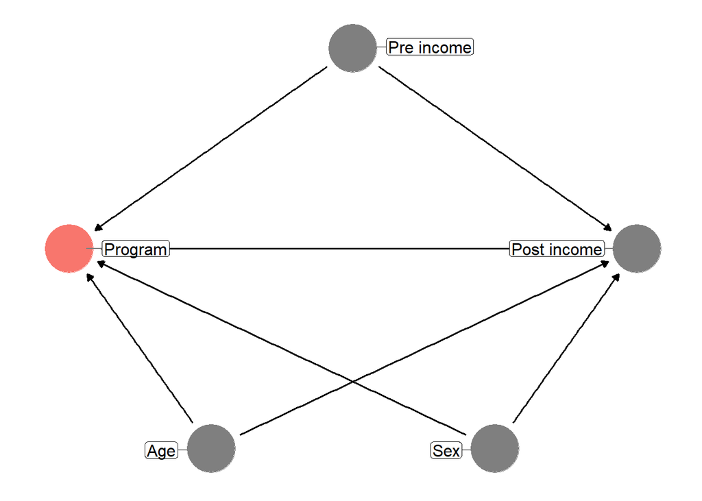

```r
income_dag <- dagify(post_income ~ program + age + sex + pre_income,
                     program ~ age + sex + pre_income,
                     exposure = "program",
                     outcome = "post_income",
                     labels = c(post_income = "Post income",
                                program = "Program",
                                age = "Age",
                                sex = "Sex",
                                pre_income = "Pre income"),
                     coords = list(x = c(program = 1, post_income = 5, age = 2,
                                         sex = 4, pre_income = 3),
                                   y = c(program = 2, post_income = 2, age = 1,
                                         sex = 1, pre_income = 3)))

ggdag_status(income_dag, use_labels = "label", text = FALSE, seed = 1234) +
  guides(color = FALSE) +
  theme_dag()
```

La ONG acaba de recibir financiación para realizar un ensayo controlado aleatorio (ECA) en una aldea y usted está entusiasmado porque finalmente puede manipular el acceso al programa: puede calcular. Siguiendo las reglas de los diagramas causales, puedes eliminar todas las flechas que van al nodo del programa:

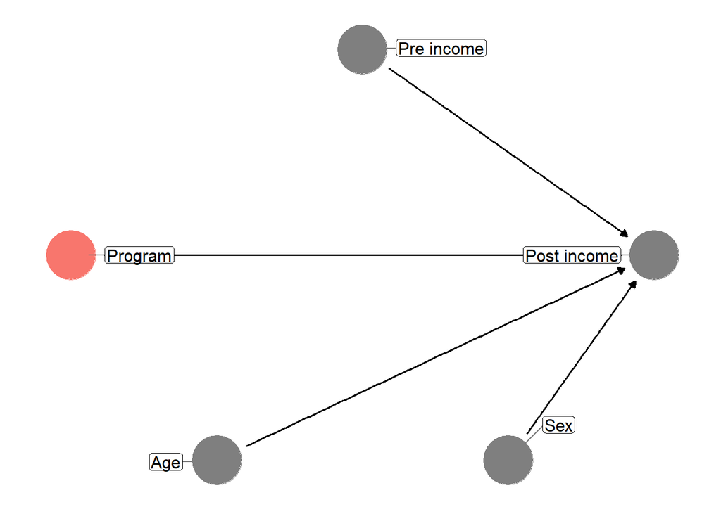

```r
income_dag_rct <- dagify(post_income ~ program + age + sex + pre_income,
                         exposure = "program",
                         outcome = "post_income",
                         labels = c(post_income = "Post income",
                                    program = "Program",
                                    age = "Age",
                                    sex = "Sex",
                                    pre_income = "Pre income"),
                         coords = list(x = c(program = 1, post_income = 5, age = 2,
                                             sex = 4, pre_income = 3),
                                       y = c(program = 2, post_income = 2, age = 1,
                                             sex = 1, pre_income = 3)))

ggdag_status(income_dag_rct, use_labels = "label", text = FALSE, seed = 1234) +
  guides(color = FALSE) +
  theme_dag()
```

## 4.2 Consultar saldo

Realizaste el estudio con 1000 participantes en el transcurso de 6 meses y acabas de recuperar tus datos.

Antes de calcular el efecto del programa, primero verifica qué tan equilibrada estuvo la asignación y descubre que la asignación al programa se dividió prácticamente 50/50, lo cual es bueno:

```r
village_randomized %>%
  count(program) %>%
  mutate(prop = n / sum(n))
```

| program | n | prop |
| --- | --- | --- |
| No program | 503 | 0.503 |
| Program | 497 | 0.497 |

Luego verifica qué tan bien equilibrados estaban los grupos de tratamiento y control en las características previas al tratamiento de los participantes:

```r
village_randomized %>%
  group_by(program) %>%
  summarize(prop_male = mean(sex_num),
            avg_age = mean(age),
            avg_pre_income = mean(pre_income))
```

| program | prop_male | avg_age | avg_pre_income |
| --- | --- | --- | --- |
| No program | 0.5844930 | 34.92445 | 803.3298 |
| Program | 0.6036217 | 34.85513 | 801.4799 |

Estas variables parecen bastante bien equilibradas. Para comprobar que no hay diferencias estadísticamente significativas entre los grupos, haga algunos gráficos (también puede ejecutar pruebas t, pero los gráficos son más fáciles de leer más tarde para su audiencia no estadística).

Hubo más hombres tanto en el grupo de tratamiento como en el de control, pero la proporción es la misma en ambos y no hay una diferencia sustancial en la proporción de sexo:

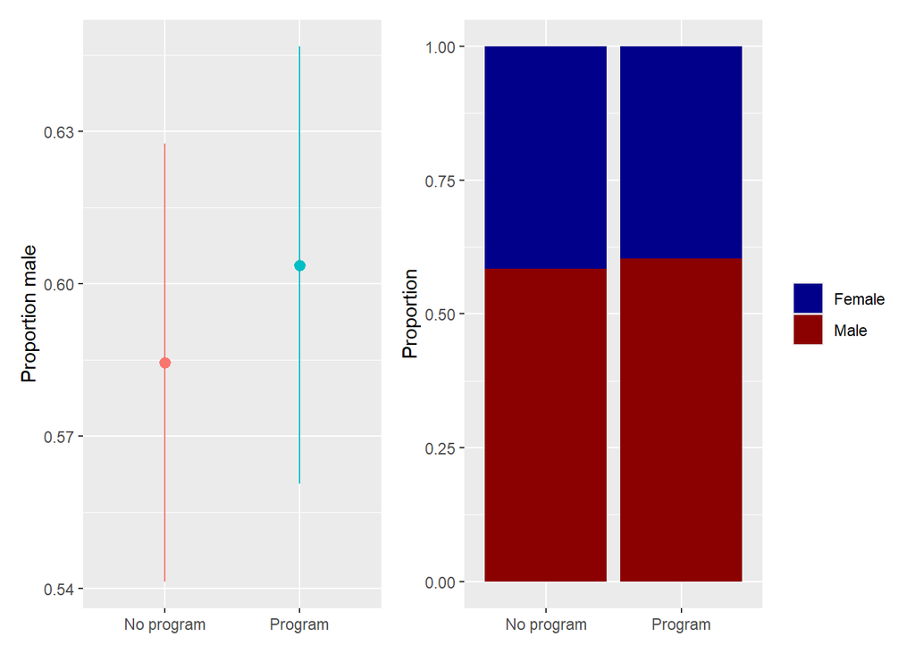

```r
# Aquí guardamos cada gráfico como un objeto para que podamos combinar los dos gráficos con
# (que viene del paquete patchwork). Si desea ver lo que un
# individual, puede ejecutar `plot_diff_sex`, o como se llame el objeto
# objeto se llama.
#
# stat_summary() aquí es un poco diferente de las capas geom_*() que has visto # en el pasado.
# stat_summary() toma una función (aquí mean_se()) y la ejecuta sobre
# cada uno de los grupos de programas para obtener la media y el error estándar. A continuación
# los traza con geom_pointrange. La parte fun.args nos permite pasar un # argumento a mean_se().
# argumento a mean_se() para que podamos multiplicar el error estándar por 1.96,
# dándonos el intervalo de confianza del 95%.

plot_diff_sex <- ggplot(village_randomized, aes(x = program, y = sex_num, color = program)) +
  stat_summary(geom = "pointrange", fun.data = "mean_se", fun.args = list(mult = 1.96)) +
  guides(color = FALSE) +
  labs(x = NULL, y = "Proportion male")
# plot_diff_sex  # Uncomment this if you want to see this plot by itself

plot_prop_sex <- ggplot(village_randomized, aes(x = program, fill = sex)) +
  # Using position = "fill" makes the bars range from 0-1 and show the proportion
  geom_bar(position = "fill") +
  labs(x = NULL, y = "Proportion", fill = NULL) +
  scale_fill_manual(values = c("darkblue", "darkred"))

# Show the plots side-by-side
plot_diff_sex + plot_prop_sex
```

La distribución de edades parece básicamente la misma en los grupos de tratamiento y control, y no hay una diferencia sustancial en la edad promedio entre los grupos:

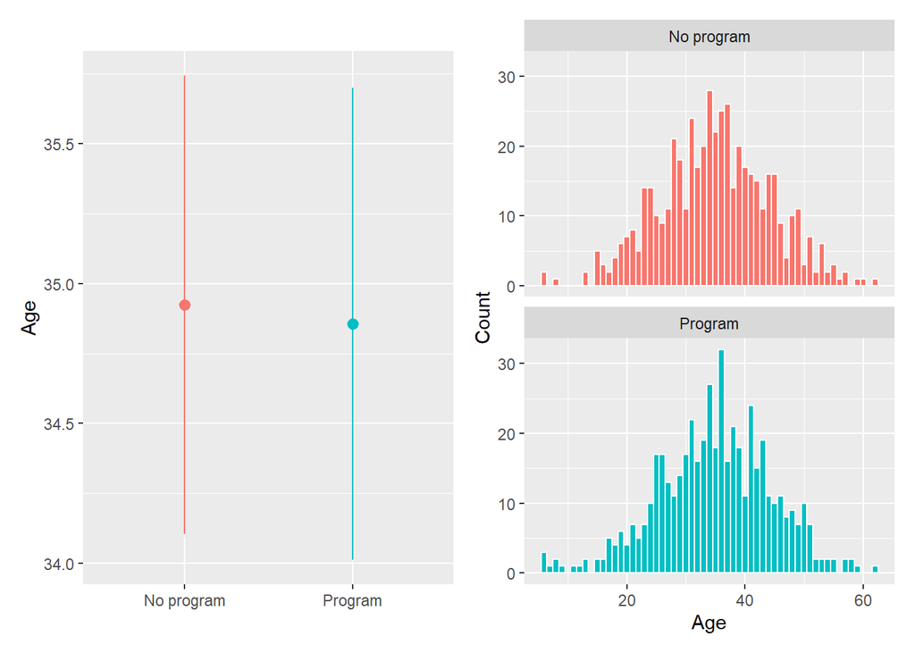

```r
plot_diff_age <- ggplot(village_randomized, aes(x = program, y = age, color = program)) +
  stat_summary(geom = "pointrange", fun.data = "mean_se", fun.args = list(mult = 1.96)) +
  guides(color = FALSE) +
  labs(x = NULL, y = "Age")

plot_hist_age <- ggplot(village_randomized, aes(x = age, fill = program)) +
  geom_histogram(binwidth = 1, color = "white") +
  guides(fill = FALSE) +
  labs(x = "Age", y = "Count") +
  facet_wrap(vars(program), ncol = 1)

plot_diff_age + plot_hist_age
```

Los ingresos previos al programa también se distribuyen de la misma manera (y no tienen diferencias sustanciales en los promedios) entre los grupos de tratamiento y control:

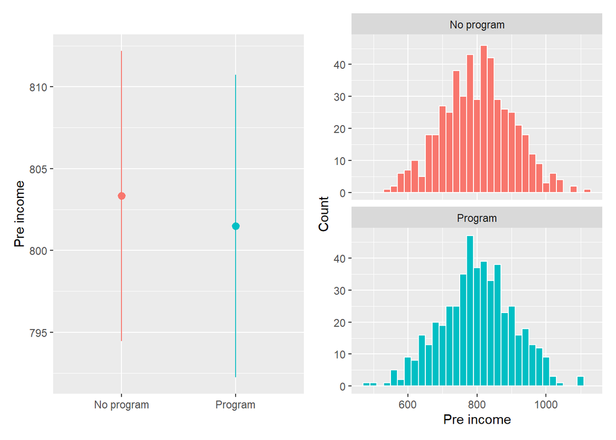

```r
plot_diff_income <- ggplot(village_randomized, aes(x = program, y = pre_income, color = program)) +
  stat_summary(geom = "pointrange", fun.data = "mean_se", fun.args = list(mult = 1.96)) +
  guides(color = FALSE) +
  labs(x = NULL, y = "Pre income")

plot_hist_income <- ggplot(village_randomized, aes(x = pre_income, fill = program)) +
  geom_histogram(binwidth = 20, color = "white") +
  guides(fill = FALSE) +
  labs(x = "Pre income", y = "Count") +
  facet_wrap(vars(program), ncol = 1)

plot_diff_income + plot_hist_income
```

¡Todas nuestras covariables previas al tratamiento se ven bien y equilibradas! Ahora puede estimar el efecto causal del programa.

## 4.3 Estimar la diferencia

stá interesado en el efecto causal del programa, o $E[\text{Post income}\ |\ do(\text{Program})]$

Puede encontrar este efecto causal calculando el efecto promedio del tratamiento:

$\text{ATE} = E(\overline{\text{Post income }} | \text{ Program} = 1) - E(\overline{\text{Post income }} | \text{ Program} = 0)$

Este es simplemente el resultado promedio de las personas en el programa menos el resultado promedio de las personas que no están en el programa. Calculas los promedios del grupo:

```r
village_randomized %>%
  group_by(program) %>%
  summarize(avg_post = mean(post_income))
```

| program | avg_post |
| --- | --- |
| No program | 1179.977 |
| Program | 1279.225 |

Eso es 1279 − 1180, o 99, lo que significa que el programa provocó un aumento de $99 en ingresos, en promedio.

Encontrar esa diferencia requirió algunos cálculos manuales, por lo que, como atajo, se ejecuta un modelo de regresión con los ingresos posteriores al programa como variable de resultado y la variable indicadora del programa como variable explicativa. El coeficiente para programes el efecto causal (e incluye información sobre errores estándar y significancia). Encuentras el mismo resultado:

```r
model_rct <- lm(post_income ~ program, data = village_randomized)
tidy(model_rct)
```

| term | estimate | std.error | statistic | p.value |
| --- | --- | --- | --- | --- |
| (Intercept) | 1179.97729 | 4.269417 | 276.37902 | 0.000000e+00 |
| programProgram | 99.24788 | 6.056063 | 16.38818 | 1.233608e-53 |

Según su ECA, concluye que el programa provoca un aumento promedio de $99,25 en los ingresos.

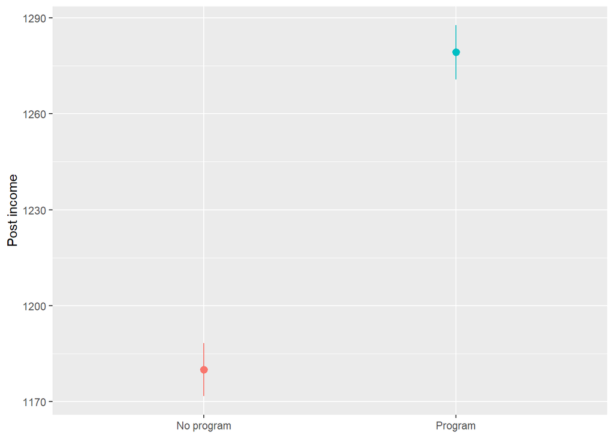

```r
ggplot(village_randomized, aes(x = program, y = post_income, color = program)) +
  stat_summary(geom = "pointrange", fun.data = "mean_se", fun.args = list(mult = 1.96)) +
  guides(color = FALSE) +
  labs(x = NULL, y = "Post income")
```

Comparemos 3 modelos como al inicio de esta sección

```r
lm(post_income ~ program, data = village_randomized) |>
  tbl_regression() |>
  modify_column_unhide(column = std.error) |>
  modify_caption("Unadjusted regression")
```

Unadjusted regression

| **Characteristic** | **Beta** | **SE**<sup>1</sup> | **95% CI**<sup>1</sup> | **p-value** |
| --- | --- | --- | --- | --- |
| program |  |  |  |  |
| No program | — | — | — |  |
| Program | 99 | 6.06 | 87, 111 | <0.001 |

<sup>1</sup> SE = Standard Error, CI = Confidence Interval

```r
lm(post_income ~ program + sex + age, data = village_randomized) |>
  tbl_regression() |>
  modify_column_unhide(column = std.error) |>
  modify_caption("Adjusted regression")
```

Adjusted regression

| **Characteristic** | **Beta** | **SE**<sup>1</sup> | **95% CI**<sup>1</sup> | **p-value** |
| --- | --- | --- | --- | --- |
| program |  |  |  |  |
| No program | — | — | — |  |
| Program | 100 | 0.362 | 99, 100 | <0.001 |
| sex |  |  |  |  |
| Female | — | — | — |  |
| Male | 20 | 0.369 | 19, 21 | <0.001 |
| age | 10 | 0.019 | 10, 10 | <0.001 |

<sup>1</sup> SE = Standard Error, CI = Confidence Interval

```r
village_randomized<- village_randomized |>
  mutate(
    program = as.numeric(as.factor(program))-1)

village_randomized %>% mutate(
    p = glm(program ~ sex_num + age , data = village_randomized, family = binomial) |> predict(type = "response"),
    ate = program / p + (1 - program) / (1 - p)
  ) |>
  as.data.frame() -> d
library(PSW)
df <- as.data.frame(d)
x <- psw(
  df,
  "program ~ sex_num + age",
  weight = "ATE",
  wt = TRUE,
  out.var = "post_income"
)
tibble(
  Characteristic = "program",
  Beta = round(x$est.wt, 1),
  SE = round(x$std.wt, 3),
  `95% CI` = glue::glue("{round(x$est.wt - 1.96 * x$std.wt, 1)}, {round(x$est.wt + 1.96 * x$std.wt, 1)}"),
  `p-value` = "<0.001"
) |>
  knitr::kable(caption = "Propensity score weighted regression")
```

Propensity score weighted regression

| Characteristic | Beta | SE | 95% CI | p-value |
| --- | --- | --- | --- | --- |
| program | 99.6 | 0.362 | 98.8, 100.3 | <0.001 |